# Chapter 2: Inference and Confidence Intervals for a Single Categorical Variable

## Example 2.1 Claims of Numbness After Automobile Accident

A 28-year-old developed pain involving the spine and the left side of her body after an automobile collision. They were actively involved in a personal litigation against the company that owned the other vehicle, and they reported constant pain and numbness in the left arm. To test their claims, researchers touched their left arm with either 1 finger or 2 fingers simultaneously while their eyes were closed. The word “touch” was said simultaneously with the presentation of the tactile stimulus so that the subject knew when to respond. She then had to indicate whether she felt 1 single touch or 2 simultaneous touches (with the double-touch stimulus, the fingertips were always spaced 2 inches apart). The subject received 100 stimuli overall; they were correct on 30 of them. Is there statistical evidence that they are intentionally answering incorrectly?

1. Identify both the population and sample of interest.

Population: all possible stimuli trials that could have been given to the 28-year old

Sample: n = 100 stimuli the 28 year-old received

2. Identify the single categorical variable of interest.

Outcome (Correctly identified the touch/Incorrectly identified the touch)

3. Identify both the parameter and statistic of interest.

Parameter: the proportion of all possible stimuli trials the 28 year old would answer correctly.

Statistic: $\hat p = 30/100 = 0.3$

4. Carry out the formal hypothesis test to address the research question.
- **Research Question** Is there statistical evidence that she is intentionally answering incorrectly?
- Hypotheses:

Wording based on research question -

Null: The 28 year-old is just guessing for all possible stimuli.

Alternative: The 28 year-old is intentionally answering incorrectly for for all possible stimuli.

Wording based on parameter -

Null: the proportion of all possible stimuli trials the 28 year old would answer correctly is equal to 0.5.

Alternative: the proportion of all possible stimuli trials the 28 year old would answer correctly is less than 0.5.

Using symbols -

$H_0: \pi = 0.5$

$H_A: \pi < 0.5$

- Estimate p-value (Carry out the simulation study to investigate this p-value, sketch or paste your simulation results here)

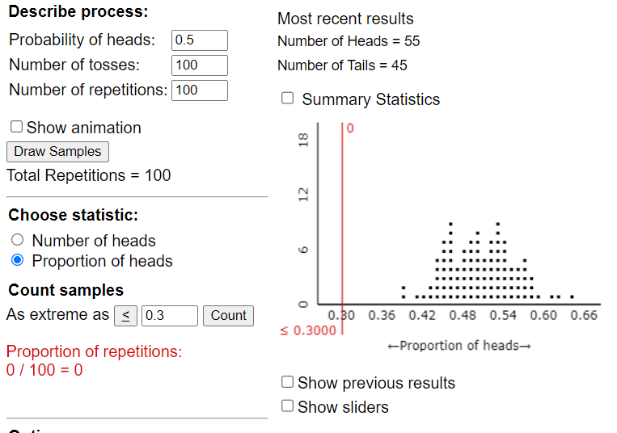

(note that when we never have a simulation set as extreme or more extreme than what we observed, the p-value is “0”, very very small!)

## Example 2.2: Effectiveness of an Experimental Drug

Suppose a commonly prescribed drug for relieving nervous tension is believed to be only 70% effective. Experimental results with a *new* drug administered to a random sample of 20 adults who were suffering from nervous tension show that 18 received relief. Is there statistical evidence that the new experimental drug is more than 70% effective?

1. Identify both the population and sample of interest.

Population: all adults suffering from nervous tension

Sample: n = 20 adults who received the new drug for nervous tension

2. Identify the single categorical variable of interest.

Relief (yes/no)

3. Identify both the parameter and statistic of interest.

Parameter: the proportion of all adults who receive relief from nervous tension

Statistic: $\hat p = 18/20 = 0.9$n

4. Carry out the formal hypothesis test to address the research question.
- **Research Question** Is there statistical evidence that the new drug is more than 70% effective?
- Hypotheses:

In words:

Null: the proportion of all adults who receive relief from nervous tension is equal to 0.7.

Alternative: the proportion of all adults who receive relief from nervous tension is greater than 0.7.

In symbols:

$H_0: \pi = 0.7$

$H_A: \pi > 0.7$

- Estimate p-value (Carry out the simulation study to investigate this p-value, sketch or paste your simulation results here)

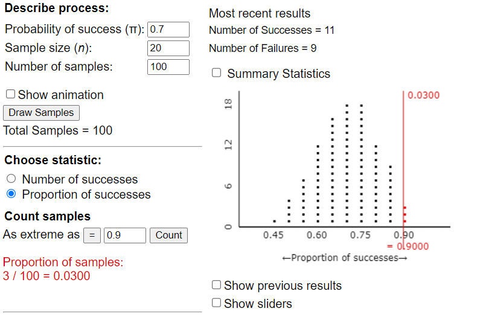

Use the simulation results to estimate the p-value: 0.03 < 0.05 -> Reject the Null

- Conclusion:

At an $\alpha = 0.05$, we have evidence to conclude the proportion of all adults who receive relief from nervous tension is greater than 0.70 (p = 0.03).